## Reproducible Research: Peer Assessment 1

### Loading and preprocessing the data

```r
rm(list=ls())
data<- read.csv("activity.csv", colClasses = c("numeric", "Date", "numeric"))
Sys.setlocale("LC_TIME", "C")
```

```
## [1] "C"
```

```r
head(data, 3)
```

```
##   steps       date interval
## 1    NA 2012-10-01        0
## 2    NA 2012-10-01        5
## 3    NA 2012-10-01       10
```

### What is mean total number of steps taken per day?

**Make a histogram of the total number of steps taken each day**

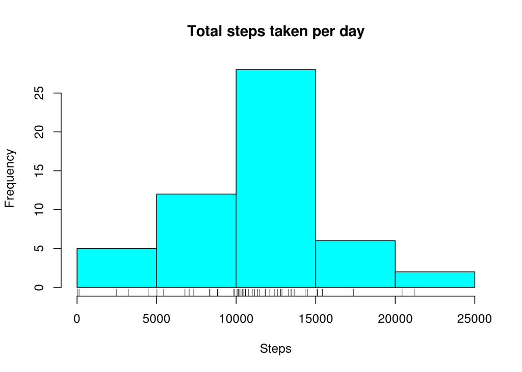

```r
datasum<- aggregate(steps~date, data = data, sum, na.rm = T)
hist(datasum$steps, col = 5,
     main = "Total steps taken per day",
     xlab = "Steps")
rug(datasum$steps)
```

### Calculate and report the mean and median total number of steps taken per day

**Mean**

```r
mean(datasum$steps)
```

```
## [1] 10766
```

**Median**

```r
median(datasum$steps)
```

```
## [1] 10765
```

### Make a time series plot (i.e. type = “l”) of the 5-minute interval (x-axis) and the average number of steps taken, averaged across all days (y-axis)

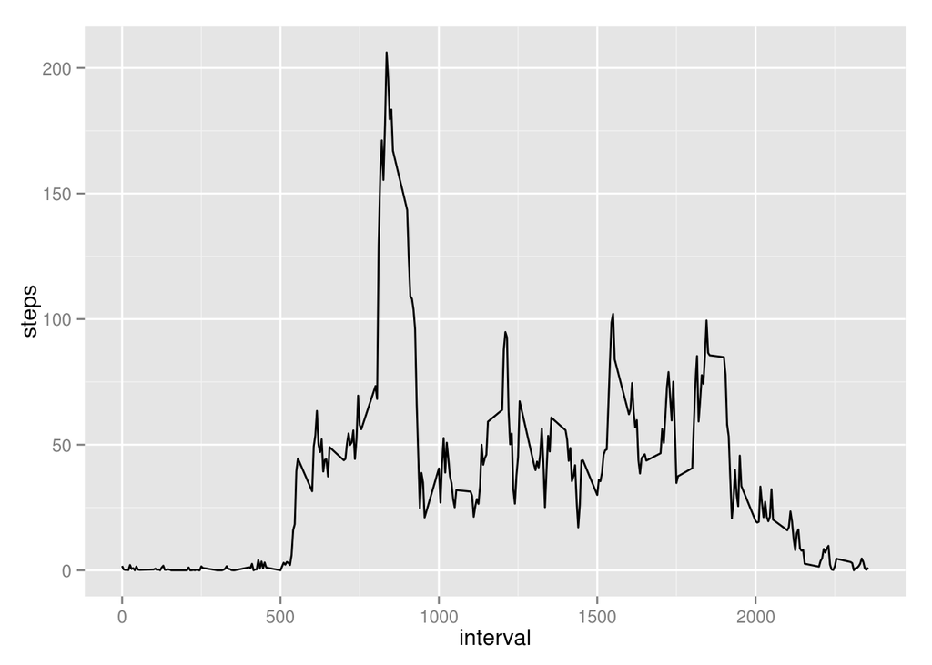

```r
library(ggplot2)
z<- aggregate(steps~interval, data = data, mean)
qplot(interval, steps, data = z, geom = "line")
```

### Which 5-minute interval, on average across all the days in the dataset, contains the maximum number of steps?

```r
which.max(z$steps)
```

```
## [1] 104
```

```r
z$interval[which.max(z$steps)]
```

```
## [1] 835
```

### Imputing missing values

**Calculate and report the total number of missing values in the dataset**

```r
sum(is.na(data$steps))
```

```
## [1] 2304
```